# DSO 545: Statistical Computing and Data Visualization

Midterm 02

Spring 2016

## Case 01: There is always Room for Icecream!

The United Nations Industrial Commodity Statistics Database provides annual statistics on the production of major industrial commodities by country. Data are provided in terms of physical quantities as well as monetary value. The online database covers the years 1995 to 2012 (Source: http://data.un.org/Data.aspx?d=ICS&f=cmID:22970-0). You can find the dataset in `icecream.csv` on blackboard.

**1.** Aggregate the dataset to find the average spending on icecream for all listed countries over the given years.

```r
setwd("C:/Users/dan_9/Desktop/DSO 545/Final exam/FINAL")
icecream <- read.csv("icecream.csv")

#### INSERT YOUR CODE HERE
glimpse(icecream)
```

```
## Observations: 395
## Variables: 3
## $ Country.or.Area (fctr) Albania, Albania, Albania, Albania, Albania, ...
## $ Year            (int) 2010, 2009, 2007, 2006, 2005, 2004, 1999, 1998...
## $ USDinMillions   (dbl) 4.387297, 8.265061, 2.289117, 1.618701, 1.0683...
```

```r
Q1p1 = icecream %>% group_by(Country.or.Area)  %>% summarise(MillionUSD = mean(USDinMillions))

# FinalAnswer:
Q1p1
```

```
## Source: local data frame [45 x 2]
##
##    Country.or.Area MillionUSD
##             (fctr)      (dbl)
## 1          Albania   3.225439
## 2          Bolivia   5.487864
## 3           Brazil 637.807535
## 4         Bulgaria  32.672548
## 5           Canada 545.672454
## 6            Chile 208.901264
## 7           Cyprus  16.868139
## 8   Czech Republic  44.165245
## 9          Denmark  97.575150
## 10         Ecuador  64.974000
## ..             ...        ...
```

**2.** Create a chloropleth map that shows the average spending on icecream for the listed countires over the given years. Your map would look as follows:

```r
#### INSERT YOUR CODE HERE
world_map = map_data("world")
world_map$region = tolower(world_map$region)
Q1p1$Country.or.Area = tolower(Q1p1$Country.or.Area)

glimpse(world_map)
```

```
## Observations: 99,338
## Variables: 6
## $ long      (dbl) -69.89912, -69.89571, -69.94219, -70.00415, -70.0661...
## $ lat       (dbl) 12.45200, 12.42300, 12.43853, 12.50049, 12.54697, 12...
## $ group     (dbl) 1, 1, 1, 1, 1, 1, 1, 1, 1, 1, 2, 2, 2, 2, 2, 2, 2, 2...
## $ order     (int) 1, 2, 3, 4, 5, 6, 7, 8, 9, 10, 12, 13, 14, 15, 16, 1...
## $ region    (chr) "aruba", "aruba", "aruba", "aruba", "aruba", "aruba"...
## $ subregion (chr) NA, NA, NA, NA, NA, NA, NA, NA, NA, NA, NA, NA, NA, ...
```

```r
countryIceCream = merge( world_map,Q1p1, by.x = "region", by.y = "Country.or.Area", all.x = T)
countryIceCream = arrange(countryIceCream, group, order)

countryIceCream$MillionUSD[is.na(countryIceCream$MillionUSD)] = 0
table(countryIceCream$MillionUSD)
```

```
##
##                0      0.581282097      0.614546478 1.66615976428571
##            68594              202              266              233
##          1.98894     2.0429754595      3.225438587      5.487864443
##              170              225              113              418
## 5.49040877933333 10.1844749322222   13.50046640375          14.1224
##             1518              145              453               74
## 15.6613105444286 16.8681393883333      18.58058711 19.7378401192857
##              164              100              132              140
##     20.092385565      28.14098365    32.2847646575 32.6725479853333
##               96              195              143              179
##  34.594196684375 36.8537038666667 44.1652451183333 49.5903481663636
##              155              315              240              214
##   54.38829247125 57.6464216690909 57.7065138322222           64.974
##              186              253              578              347
## 86.7646670472727      97.57514984  110.27110395125     168.47210785
##              274              298              571              282
##     174.74600518     180.56938106 197.409124246471      208.9012642
##              923             1985              593             2006
## 273.885329123077   545.6724544875   615.6599711875 637.807534961538
##              316            11573              562             1885
## 971.278114533333 1094.87570298333 1228.36117975556     1887.4311595
##              448              605              568              601
```

```r
glimpse(countryIceCream)
```

```
## Observations: 99,338
## Variables: 7
## $ region     (chr) "aruba", "aruba", "aruba", "aruba", "aruba", "aruba...
## $ long       (dbl) -69.89912, -69.89571, -69.94219, -70.00415, -70.066...
## $ lat        (dbl) 12.45200, 12.42300, 12.43853, 12.50049, 12.54697, 1...
## $ group      (dbl) 1, 1, 1, 1, 1, 1, 1, 1, 1, 1, 2, 2, 2, 2, 2, 2, 2, ...
## $ order      (int) 1, 2, 3, 4, 5, 6, 7, 8, 9, 10, 12, 13, 14, 15, 16, ...
## $ subregion  (chr) NA, NA, NA, NA, NA, NA, NA, NA, NA, NA, NA, NA, NA,...
## $ MillionUSD (dbl) 0, 0, 0, 0, 0, 0, 0, 0, 0, 0, 0, 0, 0, 0, 0, 0, 0, ...
```

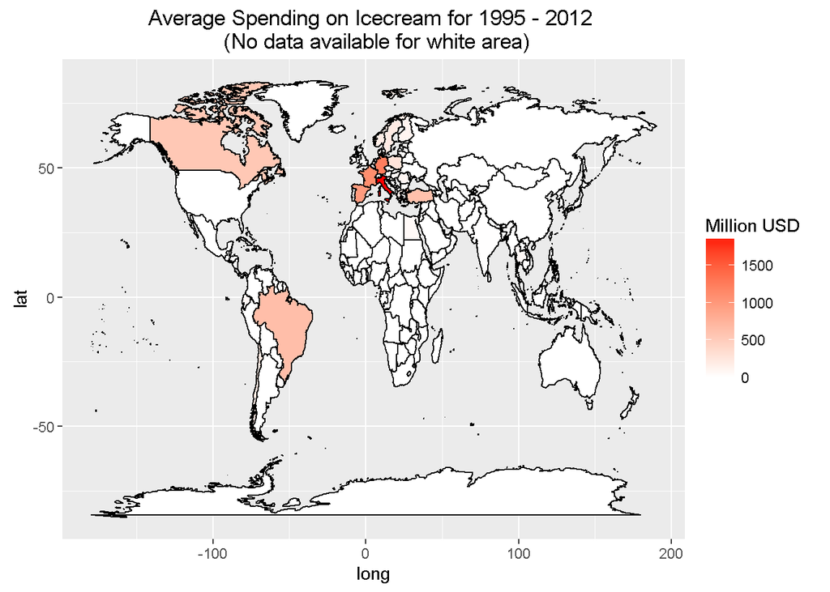

```r
# FinalAnswer:
ggplot(countryIceCream, aes(x = long, y = lat, group = group, fill = MillionUSD))+
  geom_polygon(color = "black") +
  scale_fill_continuous(low = "white", high = "red", name = "Million USD")+
  ggtitle("Average Spending on Icecream for 1995 - 2012 \n (No data available for white area)")
```

### Case 02: MLS Players Compensation

Since football season is not here yet, you might want to enjoy some soccer games for the rest of the summer? Major League Soccer (MLS) is a professional soccer league representing the sport’s highest level in both the United States and Canada. In this case, we will be scrapping the compensations for the players coming to MLS.

The wikipedia page (`http://en.wikipedia.org/wiki/Designated_Player_Rule`) has a table of those compensations!

**1.** Use `rvest` R package to scrape the data table. Save it to `players`. The xpath for the table is: `//*[@id="mw-content-text"]/table[1]`

```r
#### INSERT YOUR CODE HERE
urlC2 = "http://en.wikipedia.org/wiki/Designated_Player_Rule"
tbl = urlC2 %>%
  html() %>%
  html_nodes(xpath = '//*[@id="mw-content-text"]/table[1]' ) %>%
  html_table()
players = tbl[[1]]

# FinalAnswer:
players
```

```
##    Year signed                                          Player  Nation
## 1         2011                       Keane, RobbieRobbie Keane   Â IRL
## 2         2012             HiguaÃn, FedericoFederico HiguaÃn   Â ARG
## 3         2013                       Valeri, DiegoDiego Valeri   Â ARG
## 4         2014                       Laba, MatÃasMatÃas Laba   Â ARG
## 5         2013                     Dempsey, ClintClint Dempsey   Â USA
## 6         2013                           Diaz, MauroMauro Diaz   Â ARG
## 7         2014                              Gilberto, Gilberto   Â BRA
## 8         2014                 Bradley, MichaelMichael Bradley   Â USA
## 9         2014                         Edu, MauriceMaurice Edu   Â USA
## 10        2014                     Morales, PedroPedro Morales   Â CHI
## 11        2014                         Villa, DavidDavid Villa   Â ESP
## 12        2014                   Ridgewell, LiamLiam Ridgewell   Â ENG
## 13        2014                                    KakÃ¡, KakÃ¡   Â BRA
## 14        2014                   Piatti, IgnacioIgnacio Piatti   Â ARG
```

[output cut: 81 more lines]

**2.** Clean the column with compensation information. Change the column type to `numeric`, and rename it `Compensation`. (Hint: The dollar sign is a wild character!)

```r
#### INSERT YOUR CODE HERE

glimpse(players)
```

```
## Observations: 47
## Variables: 5
## $ Year signed                       (int) 2011, 2012, 2013, 2014, 2013...
## $ Player                            (chr) "Keane, RobbieRobbie Keane",...
## $ Nation                            (chr) "Â IRL", "Â ARG", "Â ARG", "...
## $ Current club                      (chr) "LA Galaxy", "Columbus Crew"...
## $ 2015 Guaranteed compensation [13] (chr) "$4,500,000", "$1,175,000", ...
```

```r
colnames(players)[5] = "Compensation"
players$Compensation =  str_replace_all(players$Compensation,"\\$","")
players$Compensation =  str_replace_all(players$Compensation,",","")
players$Compensation = as.numeric(players$Compensation)
C2Q2 = tbl_df(players)

# FinalAnswer:
C2Q2
```

```
## Source: local data frame [47 x 5]
##
##    Year signed                              Player Nation
##          (int)                               (chr)  (chr)
## 1         2011           Keane, RobbieRobbie Keane  Â IRL
## 2         2012 HiguaÃn, FedericoFederico HiguaÃn  Â ARG
## 3         2013           Valeri, DiegoDiego Valeri  Â ARG
## 4         2014           Laba, MatÃasMatÃas Laba  Â ARG
## 5         2013         Dempsey, ClintClint Dempsey  Â USA
## 6         2013               Diaz, MauroMauro Diaz  Â ARG
## 7         2014                  Gilberto, Gilberto  Â BRA
## 8         2014     Bradley, MichaelMichael Bradley  Â USA
## 9         2014             Edu, MauriceMaurice Edu  Â USA
## 10        2014         Morales, PedroPedro Morales  Â CHI
## ..         ...                                 ...    ...
## Variables not shown: Current club (chr), Compensation (dbl)
```

**3.** Create a subset of `players` called `NYLAplayers`, which only contains records of players currently play for `New York City FC` or `LA Galaxy`, and order your subset by `Compensation` in decreasing order. Do you know any of these big names? Let’s go down to Stubhub Center to watch them live! (Hint: You might need to rename the columns first!)

```r
#### INSERT YOUR CODE HERE

colnames(players)[4] = "CurrentClub"
NYLAplayers = players %>% filter(CurrentClub %in% c("LA Galaxy","New York City FC")) %>% arrange(desc(Compensation))

# FinalAnswer:
NYLAplayers
```

```
##   Year signed                                Player Nation
## 1        2015         Gerrard, StevenSteven Gerrard  Â ENG
## 2        2015           Lampard, FrankFrank Lampard  Â ENG
## 3        2014               Villa, DavidDavid Villa  Â ESP
## 4        2011             Keane, RobbieRobbie Keane  Â IRL
## 5        2015 dos Santos, GiovaniGiovani dos Santos  Â MEX
## 6        2015             Pirlo, AndreaAndrea Pirlo  Â ITA
##        CurrentClub Compensation
## 1        LA Galaxy      6332504
## 2 New York City FC      6000000
## 3 New York City FC      5610000
## 4        LA Galaxy      4500000
## 5        LA Galaxy      4100008
## 6 New York City FC      2315694
```

**4.** Visualize the `NYLAplayers` compensation as follows:

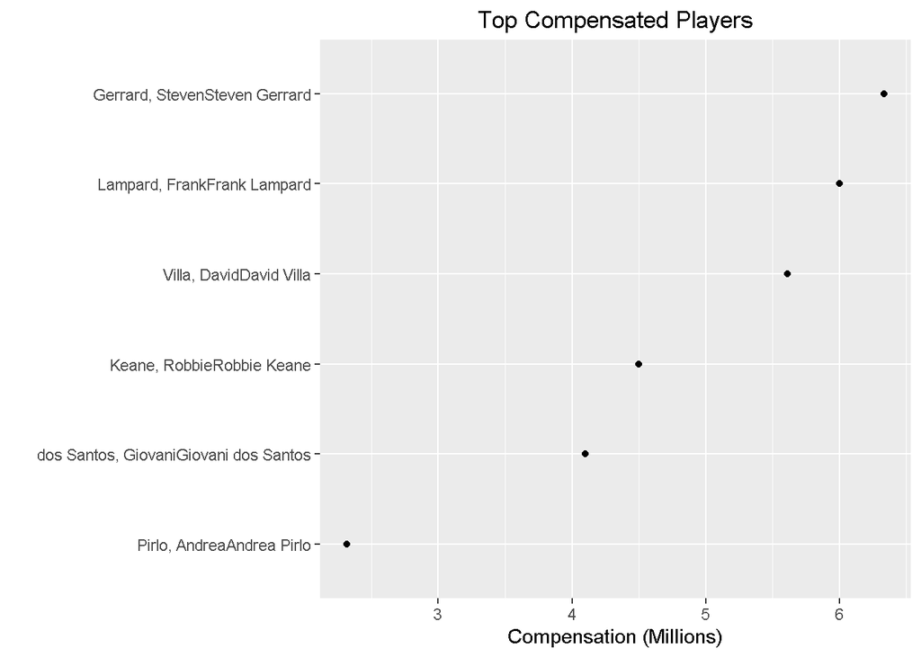

```r
#### INSERT YOUR CODE HERE

# FinalAnswer:
ggplot(NYLAplayers, aes(x = Compensation, y = reorder(Player,Compensation ))) + geom_point()+
  xlab("Compensation (Millions)") +
  ylab("")+
  ggtitle("Top Compensated Players")+
  scale_x_continuous(breaks = seq(3000000,6000000,1000000), labels =c("3", "4", "5", "6"))
```

### Case 03: How much does Joey Owe Chandler in Friends TV Show?

Have you seen Friends? In season 8 episode 22 of Friends, Joey is figuring out how much money he owes Chandler for rent, acting lessons, dance lessons, head shots, etc. How much did Joey owe Chandler?

The text files `friends.txt` summarizes a conversation between Joey and Chandler. Use `stringr` R package and regular expressions to help with the math. **What is the total amount that Joey owes Chandler**?

Hints:

1. The amounts have dollar signs
2. The $ sign is a wild character
3. Remember that most of `stringr` functions return a list. So in order to access the elements in a list, you need to use double square brackets. e.g. amount[[1]] returns the first element in a list.

```r
  # read the text file as follows
  library(stringr)
  fileName <- "friends.txt"
  text <- readChar(fileName, file.info(fileName)$size)

  #### INSERT YOUR CODE HERE

  str_locate_all(text, pattern = "\\$[0-9]*")
```

```
## [[1]]
##      start  end
## [1,]    59   63
## [2,]   196  200
## [3,]  1012 1017
## [4,]  1147 1151
## [5,]  1454 1458
## [6,]  2092 2097
```

```r
  Money = str_extract_all (text, pattern = "\\$[0-9]*")

  MoneyNoDollarSign = as.numeric(str_replace(Money[[1]], "\\$",""))
  total = sum(MoneyNoDollarSign)

  # FinalAnswer:
  total
```

```
## [1] 91760
```